# Blackjack Simulation and Analysis

Dyson Thacker

While in college a roommate of mine and I wondered if we could master the skill of counting cards in the casino game Blackjack. Many people think counting cards is illegal, which is incorrect. Counting cards is perfectly legal, but casinos don’t let people do it because it is a winning strategy and they don’t like losing money. If they catch players counting cards they just ask them to leave. The concept of counting cards is actually very straightforward. Each card has an assigned value (either 0, 1, or -1) and you just keep a running tally. If the count gets really high the player will have a higher chance of winning the next hand and they should increase their bet size. The concept is simple, but actually executing it is very tricky. If executed perfectly, counting cards changes a player’s chance of winning a hand from about 48.5% to 51%.

In every Blackjack scenario there is a mathematically best decision. People figured this out decades ago and the tables for the best decisions are very public (ex. https://www.blackjackapprenticeship.com/blackjack-strategy-charts/), but I was curious if I could make a table myself. I spent a few hours coding it up, and the results excitingly closely match the decades old decision tables.

A basic understanding of the rules of blackjack is necessary to understand most of the code.

Tutorial: https://bicyclecards.com/how-to-play/blackjack/

**Draw a card**

Below is a function that will be used to add a card to either of the Player’s or the Dealer’s hands.

```r
draw_card <- function(){
  cards <- c(1, 2, 3, 4, 5, 6, 7, 8, 9, 10, 10, 10, 10)
  sample(cards, 1)
}
```

**Hit**

Now we make a function that plays out the rest of the hand if a player chooses to Hit on their first two cards.

```r
Hit <- function(you, dealer){

  # draw card for player
  you <- you + draw_card()

  # draw cards for dealer
    while (dealer < 17) {
      dealer <- dealer + draw_card()

    }

  # test if win or lose
  if(you > 21){result <- 'lose'}
  else if(dealer > 21){result <- 'win'}
  else if(you > dealer){result <- 'win'}
  else if(you < dealer){result <- 'lose'}
  else{result <- 'tie'}
}
```

**Stay**

Here is a function that plays out the rest of the hand if a player chooses to Stay on their first two cards.

```r
Stay <- function(you, dealer){

  # draw card for player
  you <- you

  # draw cards for dealer
  while (dealer < 17) {
    dealer <- dealer + draw_card()
  }

  # test if win or lose
  if(you > 21){result <- 'lose'}
  else if(dealer > 21){result <- 'win'}
  else if(you > dealer){result <- 'win'}
  else if(you < dealer){result <- 'lose'}
  else{result <- 'tie'}
}
```

**Simulate a full hand**

Now we make a function that simulates Blackjack hands. The user inputs the sum of their own cards, the dealer’s face card, and how many hands they would like to simulate. The function then tells the user whether they should Hit or Stay based off of the results of the simulation.

```r
Blackjack <- function(you, dealer, sims){
  results_hit <- replicate(sims, Hit(you, dealer))
  result_stay <- replicate(sims, Stay(you, dealer))
  index <- 1:sims
  wins_freq_hit <- cumsum(results_hit == 'win') / index
  wins_freq_stay <- cumsum(result_stay == 'win') / index


hit_df <- data.frame(x = 1:length(wins_freq_hit), y = wins_freq_hit)
plot_hit <- ggplot(hit_df, aes(x, y)) +
  geom_line() +
  ylim(0,1) +
  scale_x_continuous(trans = "log10") +
  ylab("Percent of Hands Won") +
  xlab("Number of Hands Played") +
  ggtitle("Hit") +
  theme(plot.title = element_text(hjust = 0.5))

stay_df <- data.frame(x = 1:length(wins_freq_stay), y = wins_freq_stay)
plot_stay <- ggplot(stay_df, aes(x, y)) +
  geom_line() +
  ylim(0,1) +
  scale_x_continuous(trans = "log10") +
  ylab("Percent of Hands Won") +
  xlab("Number of Hands Played") +
  ggtitle("Stay") +
  theme(plot.title = element_text(hjust = 0.5))


grid.arrange(
    plot_hit,
    plot_stay,
    ncol = 2,
    nrow = 1,
    top = textGrob(paste0("Your Cards: ", you, ", Dealer's Card: ", dealer),
                   gp=gpar(fontsize=20,font=3))
)


  wins_freq_hit <- sum(results_hit == 'win') / (sum(results_hit == 'win') +
                                                  sum(results_hit == 'lose'))
  wins_freq_stay <- sum(result_stay == 'win') / (sum(result_stay == 'win') +
                                                   sum(result_stay == 'lose'))

  hit_if_positive <- round((wins_freq_hit - wins_freq_stay), digits = 2)
  if(wins_freq_hit >= .5){
    paste0("Dubl : ", abs(hit_if_positive))
  }
  else if(hit_if_positive >= 0){
    paste0("Hit : ",abs(hit_if_positive))
  }
  else{
    paste0("Stay : ", abs(hit_if_positive))
  }

}
```

Below is the simulation in action.

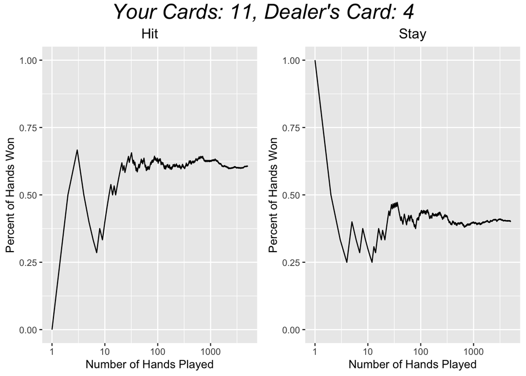

```
## [1] "Dubl : 0.25"
```

```r
Blackjack(11,4,5000)
```

**Create a Decision Table**

Finally, I run the simulation for every possible scenario in the game, and create a final decision table which can be used for playing Blackjack and counting cards.

We can view the results which can be saved and printed to be used at the casino.

```r
kbl(final_results) %>%
  kable_styling(bootstrap_options = c("striped", "hover", "condensed"), font_size = 12)
```

| Your_Cards | Dealer2 | Dealer3 | Dealer4 | Dealer5 | Dealer6 | Dealer7 | Dealer8 | Dealer9 | Dealer10 | Dealer11 |
| --- | --- | --- | --- | --- | --- | --- | --- | --- | --- | --- |
| 9 | Dubl : 0.13 | Dubl : 0.12 | Dubl : 0.13 | Dubl : 0.07 | Dubl : 0.12 | Hit : 0.21 | Hit : 0.2 | Hit : 0.1 | Hit : 0.08 | Hit : 0.11 |
| 10 | Dubl : 0.2 | Dubl : 0.21 | Dubl : 0.16 | Dubl : 0.16 | Dubl : 0.15 | Dubl : 0.33 | Dubl : 0.31 | Dubl : 0.29 | Hit : 0.22 | Hit : 0.15 |
| 11 | Dubl : 0.27 | Dubl : 0.26 | Dubl : 0.25 | Dubl : 0.25 | Dubl : 0.25 | Dubl : 0.35 | Dubl : 0.32 | Dubl : 0.29 | Dubl : 0.3 | Hit : 0.24 |
| 12 | Hit : 0.03 | Hit : 0.01 | Stay : 0.02 | Stay : 0.02 | Stay : 0.08 | Hit : 0.12 | Hit : 0.08 | Hit : 0.07 | Hit : 0.07 | Hit : 0.02 |
| 13 | Stay : 0.04 | Stay : 0.01 | Stay : 0.06 | Stay : 0.09 | Stay : 0.06 | Hit : 0.05 | Hit : 0.09 | Hit : 0.07 | Hit : 0.03 | Hit : 0.02 |
| 14 | Hit : 0 | Stay : 0.08 | Stay : 0.09 | Stay : 0.09 | Stay : 0.09 | Hit : 0.05 | Hit : 0.05 | Hit : 0.01 | Stay : 0.02 | Hit : 0 |
| 15 | Stay : 0.07 | Stay : 0.11 | Stay : 0.1 | Stay : 0.12 | Stay : 0.13 | Hit : 0.01 | Hit : 0.03 | Hit : 0.04 | Stay : 0.01 | Hit : 0.01 |
| 16 | Stay : 0.12 | Stay : 0.13 | Stay : 0.16 | Stay : 0.19 | Stay : 0.17 | Hit : 0.03 | Hit : 0.02 | Stay : 0.04 | Stay : 0.03 | Stay : 0.03 |
| 17 | Stay : 0.21 | Stay : 0.22 | Stay : 0.21 | Stay : 0.23 | Stay : 0.3 | Stay : 0.17 | Stay : 0.09 | Stay : 0.09 | Stay : 0.06 | Stay : 0.09 |
| 18 | Stay : 0.46 | Stay : 0.45 | Stay : 0.45 | Stay : 0.41 | Stay : 0.43 | Stay : 0.52 | Stay : 0.42 | Stay : 0.21 | Stay : 0.2 | Stay : 0.21 |
| 19 | Stay : 0.59 | Stay : 0.57 | Stay : 0.62 | Stay : 0.62 | Stay : 0.62 | Stay : 0.67 | Stay : 0.71 | Stay : 0.66 | Stay : 0.4 | Stay : 0.39 |
| 20 | Stay : 0.8 | Stay : 0.81 | Stay : 0.81 | Stay : 0.82 | Stay : 0.81 | Stay : 0.85 | Stay : 0.82 | Stay : 0.83 | Stay : 0.8 | Stay : 0.55 |

**Considerations for Future Updates**

The main thing this analysis does not account for is the fact that aces can be worth 1 or 11. If I wanted to add this to the dealer’s decision matrix it wouldn’t be too hard as the dealer strictly keeps hitting until they have 17 or higher. However, adding 1 or 11 to the player’s decision making would be quite difficult because it would require adding the ability to hit more than once, and the simulation would need to be completely rewritten.

Maybe someday down the road :)